# IP5_JRR

## Exploratory Data Analysis

**Author:** Jacob Redmon  
**Version:** 1.0  
**Semester:** Spring 2021  
**Summary:**

The goal of this project is to use R and TidyVerse to clean up a data set and explore it by recreating IP4.

## I. Imports

```r
library(datasets)
library(tidyverse)
library(psych)
library(corrplot)
```

## II. Data Set Description

```r
df <- read.csv("movie_metadata.csv")
head(df)
```

```
##   color     director_name num_critic_for_reviews duration
## 1 Color     James Cameron                    723      178
## 2 Color    Gore Verbinski                    302      169
## 3 Color        Sam Mendes                    602      148
## 4 Color Christopher Nolan                    813      164
## 5             Doug Walker                     NA       NA
## 6 Color    Andrew Stanton                    462      132
##   director_facebook_likes actor_3_facebook_likes     actor_2_name
## 1                       0                    855 Joel David Moore
## 2                     563                   1000    Orlando Bloom
## 3                       0                    161     Rory Kinnear
## 4                   22000                  23000   Christian Bale
## 5                     131                     NA       Rob Walker
## 6                     475                    530  Samantha Morton
##   actor_1_facebook_likes     gross                          genres
```

[output cut: 55 more lines]

```r
str(df)
```

```
## 'data.frame':    5043 obs. of  28 variables:
##  $ color                    : chr  "Color" "Color" "Color" "Color" ...
##  $ director_name            : chr  "James Cameron" "Gore Verbinski" "Sam Mendes" "Christopher Nolan" ...
##  $ num_critic_for_reviews   : int  723 302 602 813 NA 462 392 324 635 375 ...
##  $ duration                 : int  178 169 148 164 NA 132 156 100 141 153 ...
##  $ director_facebook_likes  : int  0 563 0 22000 131 475 0 15 0 282 ...
##  $ actor_3_facebook_likes   : int  855 1000 161 23000 NA 530 4000 284 19000 10000 ...
##  $ actor_2_name             : chr  "Joel David Moore" "Orlando Bloom" "Rory Kinnear" "Christian Bale" ...
##  $ actor_1_facebook_likes   : int  1000 40000 11000 27000 131 640 24000 799 26000 25000 ...
##  $ gross                    : int  760505847 309404152 200074175 448130642 NA 73058679 336530303 200807262 458991599 301956980 ...
##  $ genres                   : chr  "Action|Adventure|Fantasy|Sci-Fi" "Action|Adventure|Fantasy" "Action|Adventure|Thriller" "Action|Thriller" ...
##  $ actor_1_name             : chr  "CCH Pounder" "Johnny Depp" "Christoph Waltz" "Tom Hardy" ...
##  $ movie_title              : chr  "AvatarÂ " "Pirates of the Caribbean: At World's EndÂ " "SpectreÂ " "The Dark Knight RisesÂ " ...
##  $ num_voted_users          : int  886204 471220 275868 1144337 8 212204 383056 294810 462669 321795 ...
##  $ cast_total_facebook_likes: int  4834 48350 11700 106759 143 1873 46055 2036 92000 58753 ...
##  $ actor_3_name             : chr  "Wes Studi" "Jack Davenport" "Stephanie Sigman" "Joseph Gordon-Levitt" ...
##  $ facenumber_in_poster     : int  0 0 1 0 0 1 0 1 4 3 ...
##  $ plot_keywords            : chr  "avatar|future|marine|native|paraplegic" "goddess|marriage ceremony|marriage proposal|pirate|singapore" "bomb|espionage|sequel|spy|terrorist" "deception|imprisonment|lawlessness|police officer|terrorist plot" ...
##  $ movie_imdb_link          : chr  "http://www.imdb.com/title/tt0499549/?ref_=fn_tt_tt_1" "http://www.imdb.com/title/tt0449088/?ref_=fn_tt_tt_1" "http://www.imdb.com/title/tt2379713/?ref_=fn_tt_tt_1" "http://www.imdb.com/title/tt1345836/?ref_=fn_tt_tt_1" ...
##  $ num_user_for_reviews     : int  3054 1238 994 2701 NA 738 1902 387 1117 973 ...
##  $ language                 : chr  "English" "English" "English" "English" ...
##  $ country                  : chr  "USA" "USA" "UK" "USA" ...
##  $ content_rating           : chr  "PG-13" "PG-13" "PG-13" "PG-13" ...
##  $ budget                   : num  2.37e+08 3.00e+08 2.45e+08 2.50e+08 NA ...
##  $ title_year               : int  2009 2007 2015 2012 NA 2012 2007 2010 2015 2009 ...
##  $ actor_2_facebook_likes   : int  936 5000 393 23000 12 632 11000 553 21000 11000 ...
##  $ imdb_score               : num  7.9 7.1 6.8 8.5 7.1 6.6 6.2 7.8 7.5 7.5 ...
##  $ aspect_ratio             : num  1.78 2.35 2.35 2.35 NA 2.35 2.35 1.85 2.35 2.35 ...
##  $ movie_facebook_likes     : int  33000 0 85000 164000 0 24000 0 29000 118000 10000 ...
```

The columns are not in any particular, so I’ll sort them in a more meaningful way.

```r
col_order <- c('movie_title', 'title_year', 'country', 'language', 'budget', 'gross', 'imdb_score', 'duration', 'genres', 'plot_keywords', 'color', 'content_rating', 'aspect_ratio', 'facenumber_in_poster', 'num_critic_for_reviews', 'num_user_for_reviews', 'num_voted_users', 'director_name', 'actor_1_name', 'actor_2_name', 'actor_3_name', 'director_facebook_likes', 'actor_1_facebook_likes','actor_2_facebook_likes', 'actor_3_facebook_likes', 'cast_total_facebook_likes', 'movie_facebook_likes', 'movie_imdb_link')
dfa <- df[, col_order]
str(dfa)
```

```
## 'data.frame':    5043 obs. of  28 variables:
##  $ movie_title              : chr  "AvatarÂ " "Pirates of the Caribbean: At World's EndÂ " "SpectreÂ " "The Dark Knight RisesÂ " ...
##  $ title_year               : int  2009 2007 2015 2012 NA 2012 2007 2010 2015 2009 ...
##  $ country                  : chr  "USA" "USA" "UK" "USA" ...
##  $ language                 : chr  "English" "English" "English" "English" ...
##  $ budget                   : num  2.37e+08 3.00e+08 2.45e+08 2.50e+08 NA ...
##  $ gross                    : int  760505847 309404152 200074175 448130642 NA 73058679 336530303 200807262 458991599 301956980 ...
##  $ imdb_score               : num  7.9 7.1 6.8 8.5 7.1 6.6 6.2 7.8 7.5 7.5 ...
##  $ duration                 : int  178 169 148 164 NA 132 156 100 141 153 ...
##  $ genres                   : chr  "Action|Adventure|Fantasy|Sci-Fi" "Action|Adventure|Fantasy" "Action|Adventure|Thriller" "Action|Thriller" ...
##  $ plot_keywords            : chr  "avatar|future|marine|native|paraplegic" "goddess|marriage ceremony|marriage proposal|pirate|singapore" "bomb|espionage|sequel|spy|terrorist" "deception|imprisonment|lawlessness|police officer|terrorist plot" ...
##  $ color                    : chr  "Color" "Color" "Color" "Color" ...
##  $ content_rating           : chr  "PG-13" "PG-13" "PG-13" "PG-13" ...
##  $ aspect_ratio             : num  1.78 2.35 2.35 2.35 NA 2.35 2.35 1.85 2.35 2.35 ...
##  $ facenumber_in_poster     : int  0 0 1 0 0 1 0 1 4 3 ...
##  $ num_critic_for_reviews   : int  723 302 602 813 NA 462 392 324 635 375 ...
##  $ num_user_for_reviews     : int  3054 1238 994 2701 NA 738 1902 387 1117 973 ...
##  $ num_voted_users          : int  886204 471220 275868 1144337 8 212204 383056 294810 462669 321795 ...
##  $ director_name            : chr  "James Cameron" "Gore Verbinski" "Sam Mendes" "Christopher Nolan" ...
##  $ actor_1_name             : chr  "CCH Pounder" "Johnny Depp" "Christoph Waltz" "Tom Hardy" ...
##  $ actor_2_name             : chr  "Joel David Moore" "Orlando Bloom" "Rory Kinnear" "Christian Bale" ...
##  $ actor_3_name             : chr  "Wes Studi" "Jack Davenport" "Stephanie Sigman" "Joseph Gordon-Levitt" ...
##  $ director_facebook_likes  : int  0 563 0 22000 131 475 0 15 0 282 ...
##  $ actor_1_facebook_likes   : int  1000 40000 11000 27000 131 640 24000 799 26000 25000 ...
##  $ actor_2_facebook_likes   : int  936 5000 393 23000 12 632 11000 553 21000 11000 ...
##  $ actor_3_facebook_likes   : int  855 1000 161 23000 NA 530 4000 284 19000 10000 ...
##  $ cast_total_facebook_likes: int  4834 48350 11700 106759 143 1873 46055 2036 92000 58753 ...
##  $ movie_facebook_likes     : int  33000 0 85000 164000 0 24000 0 29000 118000 10000 ...
##  $ movie_imdb_link          : chr  "http://www.imdb.com/title/tt0499549/?ref_=fn_tt_tt_1" "http://www.imdb.com/title/tt0449088/?ref_=fn_tt_tt_1" "http://www.imdb.com/title/tt2379713/?ref_=fn_tt_tt_1" "http://www.imdb.com/title/tt1345836/?ref_=fn_tt_tt_1" ...
```

```r
describe(dfa)
```

```
##                           vars    n        mean           sd      median
## movie_title*                 1 5043     2458.84      1419.27     2460.00
## title_year                   2 4935     2002.47        12.47     2005.00
## country*                     3 5043       58.56        15.63       65.00
## language*                    4 5043       13.66         3.92       13.00
## budget                       5 4551 39752620.44 206114898.45 20000000.00
## gross                        6 4159 48468407.53  68452990.44 25517500.00
## imdb_score                   7 5043        6.44         1.13        6.60
## duration                     8 5028      107.20        25.20      103.00
## genres*                      9 5043      560.33       258.38      617.00
## plot_keywords*              10 5043     2310.23      1415.57     2309.00
## color*                      11 5043        2.95         0.23        3.00
## content_rating*             12 5043        9.58         2.92       10.00
## aspect_ratio                13 4714        2.22         1.39        2.35
## facenumber_in_poster        14 5030        1.37         2.01        1.00
## num_critic_for_reviews      15 4993      140.19       121.60      110.00
## num_user_for_reviews        16 5022      272.77       377.98      156.00
## num_voted_users             17 5043    83668.16    138485.26    34359.00
## director_name*              18 5043     1220.09       712.80     1228.00
## actor_1_name*               19 5043     1042.20       602.86     1029.00
## actor_2_name*               20 5043     1510.24       884.07     1506.00
## actor_3_name*               21 5043     1772.41      1026.44     1775.00
## director_facebook_likes     22 4939      686.51      2813.33       49.00
## actor_1_facebook_likes      23 5036     6560.05     15020.76      988.00
## actor_2_facebook_likes      24 5030     1651.75      4042.44      595.00
## actor_3_facebook_likes      25 5020      645.01      1665.04      371.50
## cast_total_facebook_likes   26 5043     9699.06     18163.80     3090.00
## movie_facebook_likes        27 5043     7525.96     19320.45      166.00
## movie_imdb_link*            28 5043     2463.16      1421.81     2467.00
##                               trimmed         mad     min          max
## movie_title*                  2458.94     1826.56    1.00 4.917000e+03
## title_year                    2004.59        8.90 1916.00 2.016000e+03
## country*                        63.08        0.00    1.00 6.600000e+01
## language*                       13.00        0.00    1.00 4.800000e+01
## budget                    25098686.09 23721600.00  218.00 1.221550e+10
## gross                     34169551.73 34457302.30  162.00 7.605058e+08
## imdb_score                       6.52        1.04    1.60 9.500000e+00
## duration                       105.24       17.79    7.00 5.110000e+02
## genres*                        578.99      272.80    1.00 9.140000e+02
## plot_keywords*                2307.80     1825.08    1.00 4.761000e+03
```

[output cut: 32 more lines]

```
## facenumber_in_poster      4.300000e+01  4.38    51.96       0.03
## num_critic_for_reviews    8.120000e+02  1.52     2.91       1.72
## num_user_for_reviews      5.059000e+03  4.12    26.40       5.33
## num_voted_users           1.689759e+06  4.03    24.41    1950.11
## director_name*            2.398000e+03 -0.08    -1.23      10.04
## actor_1_name*             2.097000e+03  0.00    -1.18       8.49
## actor_2_name*             3.032000e+03  0.01    -1.22      12.45
## actor_3_name*             3.521000e+03 -0.02    -1.22      14.45
## director_facebook_likes   2.300000e+04  5.23    27.22      40.03
## actor_1_facebook_likes    6.400000e+05 19.11   682.60     211.66
## actor_2_facebook_likes    1.370000e+05  9.88   256.44      57.00
## actor_3_facebook_likes    2.300000e+04  7.27    60.48      23.50
## cast_total_facebook_likes 6.567300e+05 12.82   360.75     255.78
## movie_facebook_likes      3.490000e+05  5.06    41.27     272.06
## movie_imdb_link*          4.918000e+03 -0.01    -1.20      20.02
```

There are many columns here that have missing data, I will remove all rows with missing data in any column and still be left with a sizeable data set. I will also reset the index since it is no longer continuous after dropping the missing data. The `aspect_ratio` column was messed up in the original data set as it should be a String but it is a float and now no longer makes sense, so I will drop the whole column.

```r
dfa <- subset(dfa, select=-c(aspect_ratio))
dfa <- dfa[complete.cases(dfa), ]
row.names(dfa) <- NULL
nrow(dfa)
```

```
## [1] 3873
```

The `genres` column is too verbose, so I will create an additional column that takes just the first genre in the list, which is unfortunately in alphabetical order, so it may nor be the most accurate.

```r
dfa$first_genre <- gsub('\\|.*','',dfa$genre)
head(dfa)
```

```
##                                  movie_title title_year country language
## 1                                   AvatarÂ        2009     USA  English
## 2 Pirates of the Caribbean: At World's EndÂ        2007     USA  English
## 3                                  SpectreÂ        2015      UK  English
## 4                    The Dark Knight RisesÂ        2012     USA  English
## 5                              John CarterÂ        2012     USA  English
## 6                             Spider-Man 3Â        2007     USA  English
##      budget     gross imdb_score duration                          genres
## 1 237000000 760505847        7.9      178 Action|Adventure|Fantasy|Sci-Fi
## 2 300000000 309404152        7.1      169        Action|Adventure|Fantasy
## 3 245000000 200074175        6.8      148       Action|Adventure|Thriller
## 4 250000000 448130642        8.5      164                 Action|Thriller
## 5 263700000  73058679        6.6      132         Action|Adventure|Sci-Fi
## 6 258000000 336530303        6.2      156        Action|Adventure|Romance
##                                                      plot_keywords color
```

[output cut: 48 more lines]

## III. Data Set Summary Statistics

Generate the Summary Statistics table.

```r
dfb <- subset(dfa, select=-c(movie_title, country, language, genres, plot_keywords, color, content_rating, director_name, actor_1_name, actor_2_name, actor_3_name, movie_imdb_link, first_genre))
describe(dfb)
```

```
##                           vars    n        mean           sd     median
## title_year                   1 3873     2003.08         9.95     2005.0
## budget                       2 3873 45261367.36 222869166.74 24000000.0
## gross                        3 3873 51103013.21  69787670.26 28045540.0
## imdb_score                   4 3873        6.46         1.06        6.6
## duration                     5 3873      109.95        22.67      106.0
## facenumber_in_poster         6 3873        1.38         2.06        1.0
## num_critic_for_reviews       7 3873      163.38       123.80      134.0
## num_user_for_reviews         8 3873      327.94       408.29      203.0
## num_voted_users              9 3873   102798.16    150713.11    50919.0
## director_facebook_likes     10 3873      784.48      3024.29       58.0
## actor_1_facebook_likes      11 3873     7603.00     15389.73     1000.0
## actor_2_facebook_likes      12 3873     1976.34      4492.13      664.0
## actor_3_facebook_likes      13 3873      754.34      1868.42      427.0
## cast_total_facebook_likes   14 3873    11300.83     18957.39     3903.0
## movie_facebook_likes        15 3873     9110.98     21193.85      209.0
##                               trimmed         mad    min          max
## title_year                    2004.34        7.41 1920.0 2.016000e+03
## budget                    29680033.46 25204200.00  218.0 1.221550e+10
## gross                     36735072.63 36364831.77  162.0 7.605058e+08
## imdb_score                       6.53        1.04    1.6 9.300000e+00
## duration                       107.30       17.79   34.0 3.300000e+02
## facenumber_in_poster             0.99        1.48    0.0 4.300000e+01
## num_critic_for_reviews         146.39      103.78    1.0 8.130000e+02
## num_user_for_reviews           247.95      179.39    1.0 5.060000e+03
## num_voted_users              70865.98    59179.46    5.0 1.689764e+06
## director_facebook_likes        120.27       85.99    0.0 2.300000e+04
## actor_1_facebook_likes        5367.98     1372.89    0.0 6.400000e+05
## actor_2_facebook_likes         799.61      452.19    0.0 1.370000e+05
## actor_3_facebook_likes         438.98      370.65    0.0 2.300000e+04
## cast_total_facebook_likes     8022.04     4449.28    0.0 6.567300e+05
## movie_facebook_likes          3970.58      309.86    0.0 3.490000e+05
##                                  range  skew kurtosis         se
## title_year                9.600000e+01 -2.15     9.10       0.16
## budget                    1.221550e+10 44.66  2333.33 3581180.75
## gross                     7.605057e+08  3.06    14.20 1121385.54
## imdb_score                7.700000e+00 -0.73     1.12       0.02
## duration                  2.960000e+02  2.35    12.34       0.36
## facenumber_in_poster      4.300000e+01  4.84    60.48       0.03
## num_critic_for_reviews    8.120000e+02  1.42     2.52       1.99
## num_user_for_reviews      5.059000e+03  3.86    22.74       6.56
## num_voted_users           1.689759e+06  3.68    20.34    2421.74
## director_facebook_likes   2.300000e+04  4.83    23.05      48.60
## actor_1_facebook_likes    6.400000e+05 20.27   759.42     247.29
## actor_2_facebook_likes    1.370000e+05  9.08   215.11      72.18
## actor_3_facebook_likes    2.300000e+04  6.46    47.11      30.02
## cast_total_facebook_likes 6.567300e+05 12.87   370.95     304.62
## movie_facebook_likes      3.490000e+05  4.58    34.27     340.55
```

Generate the Proportions tables for the categorical variables.

Function to calculate the proportion for categorical variables.

```r
proportion <- function(x) {
    x <- x / 3873 * 100
}
```

Generate for proportion tables for categorical variables, the Reasonable Ones.

```r
by_country <- dfa %>% count(country)
by_country <- within(by_country, prop <- proportion(by_country[2]))
by_country
```

```
##           country    n           n
## 1     Afghanistan    1  0.02581978
## 2       Argentina    3  0.07745933
## 3           Aruba    1  0.02581978
## 4       Australia   41  1.05861090
## 5         Belgium    2  0.05163956
## 6          Brazil    5  0.12909889
## 7          Canada   63  1.62664601
## 8           Chile    1  0.02581978
## 9           China   15  0.38729667
## 10       Colombia    1  0.02581978
## 11 Czech Republic    3  0.07745933
## 12        Denmark    9  0.23237800
## 13        Finland    1  0.02581978
## 14         France  105  2.71107668
```

[output cut: 33 more lines]

```r
by_language <- dfa %>% count(language)
by_language <- within(by_language, prop <- proportion(by_language[2]))
by_language
```

```
##      language    n           n
## 1                3  0.07745933
## 2  Aboriginal    2  0.05163956
## 3      Arabic    1  0.02581978
## 4     Aramaic    1  0.02581978
## 5     Bosnian    1  0.02581978
## 6   Cantonese    8  0.20655822
## 7       Czech    1  0.02581978
## 8      Danish    3  0.07745933
## 9        Dari    2  0.05163956
## 10      Dutch    3  0.07745933
## 11   Dzongkha    1  0.02581978
## 12    English 3690 95.27498064
## 13   Filipino    1  0.02581978
## 14     French   37  0.95533178
```

[output cut: 25 more lines]

```r
by_color <- dfa %>% count(color)
by_color <- within(by_color, prop <- proportion(by_color[2]))
by_color
```

```
##              color    n           n
## 1                     1  0.02581978
## 2  Black and White  131  3.38239091
## 3            Color 3741 96.59178931
```

```r
by_content_rating <- dfa %>% count(content_rating)
by_content_rating <- within(by_content_rating, prop <- proportion(by_content_rating[2]))
by_content_rating
```

```
##    content_rating    n           n
## 1                   46  1.18770979
## 2        Approved   17  0.43893623
## 3               G   89  2.29796024
## 4              GP    1  0.02581978
## 5               M    2  0.05163956
## 6           NC-17    6  0.15491867
## 7       Not Rated   40  1.03279112
## 8          Passed    3  0.07745933
## 9              PG  574 14.82055254
## 10          PG-13 1325 34.21120578
## 11              R 1736 44.82313452
## 12        Unrated   24  0.61967467
## 13              X   10  0.25819778
```

```r
by_first_genre <- dfa %>% count(first_genre)
by_first_genre <- within(by_first_genre, prop <- proportion(by_first_genre[2]))
by_first_genre
```

```
##    first_genre    n           n
## 1       Action  968 24.99354506
## 2    Adventure  375  9.68241673
## 3    Animation   45  1.16189001
## 4    Biography  207  5.34469404
## 5       Comedy 1035 26.72347018
## 6        Crime  260  6.71314227
## 7  Documentary   38  0.98115156
## 8        Drama  700 18.07384456
## 9       Family    3  0.07745933
## 10     Fantasy   37  0.95533178
## 11      Horror  164  4.23444358
## 12     Musical    2  0.05163956
## 13     Mystery   23  0.59385489
## 14     Romance    2  0.05163956
## 15      Sci-Fi    8  0.20655822
## 16    Thriller    3  0.07745933
## 17     Western    3  0.07745933
```

Generate proportion tables for categorical variables, the Ones Who Shall Not Be Printed (because they’re way too long).

```r
by_plot_keywords <- dfa %>% count(plot_keywords)
by_plot_keywords <- within(by_plot_keywords, prop <- proportion(by_plot_keywords[2]))
by_plot_keywords

by_director_name <- dfa %>% count(director_name)
by_director_name <- within(by_director_name, prop <- proportion(by_director_name[2]))
by_director_name

by_actor_1_name <- dfa %>% count(actor_1_name)
by_actor_1_name <- within(by_actor_1_name, prop <- proportion(by_actor_1_name[2]))
by_actor_1_name

by_actor_2_name <- dfa %>% count(actor_2_name)
by_actor_2_name <- within(by_actor_2_name, prop <- proportion(by_actor_2_name[2]))
by_actor_2_name

by_actor_3_name <- dfa %>% count(actor_3_name)
by_actor_3_name <- within(by_actor_3_name, prop <- proportion(by_actor_3_name[2]))
by_actor_3_name
```

Generate a correlation matrix for all continuous variables

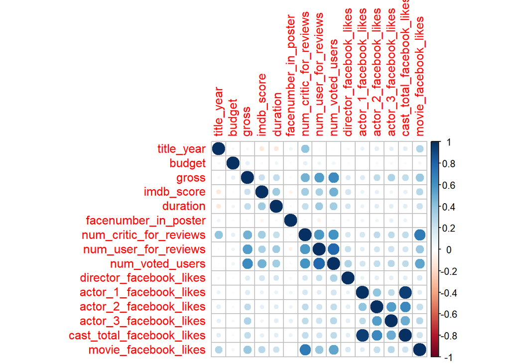

```r
corr <- cor(dfb, use = "complete.obs")
corrplot(corr, type='full')
```

## IV. Data Set Graphical Exploration

### *A. Distributions*

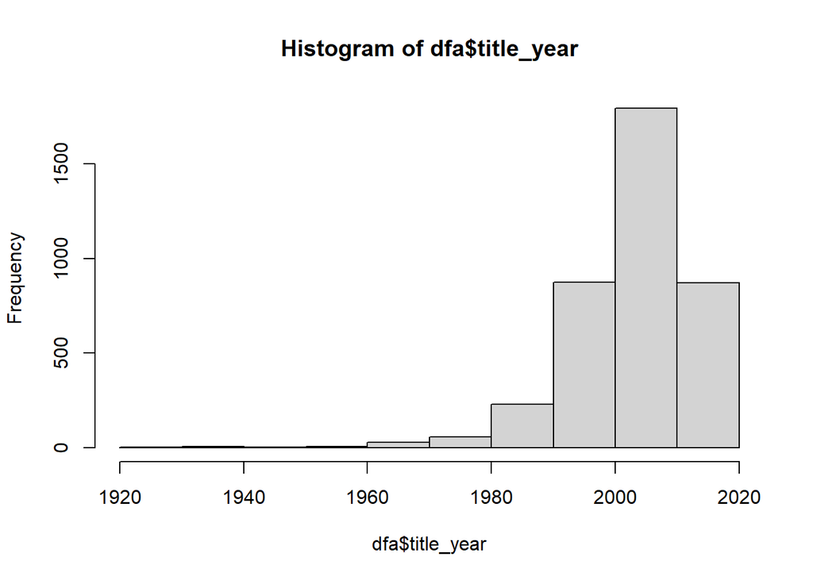

```r
hist(dfa$title_year)
```

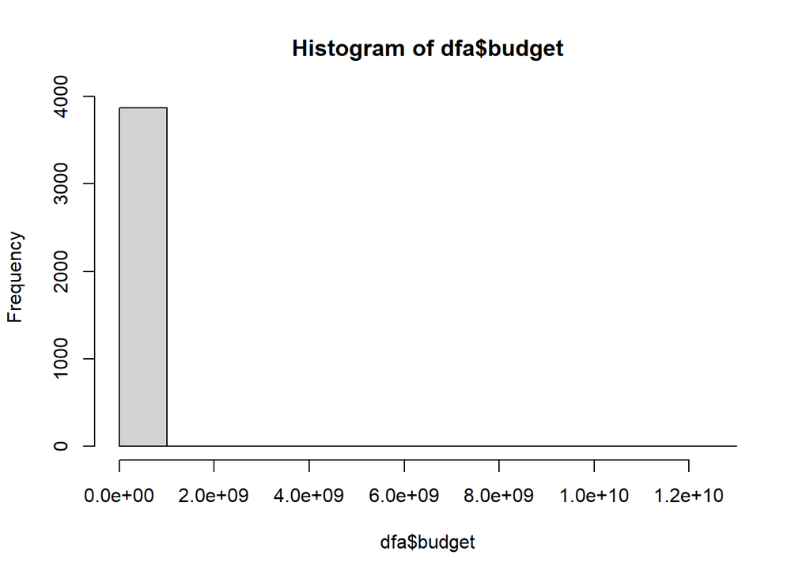

```r
hist(dfa$budget)
```

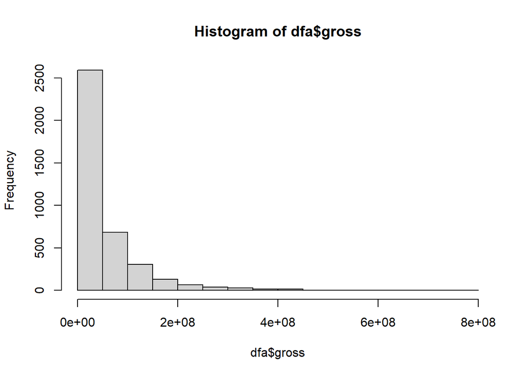

```r
hist(dfa$gross)
```

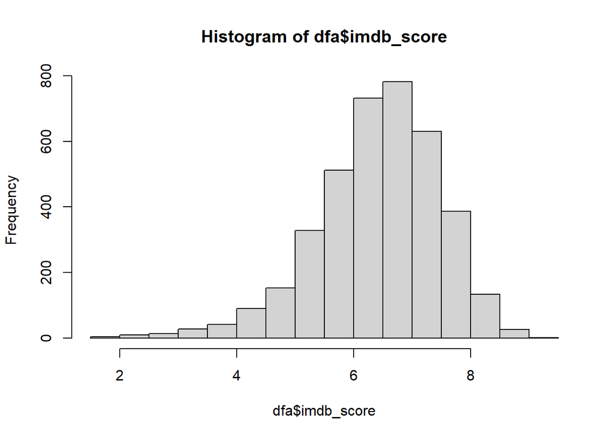

```r
hist(dfa$imdb_score)
```

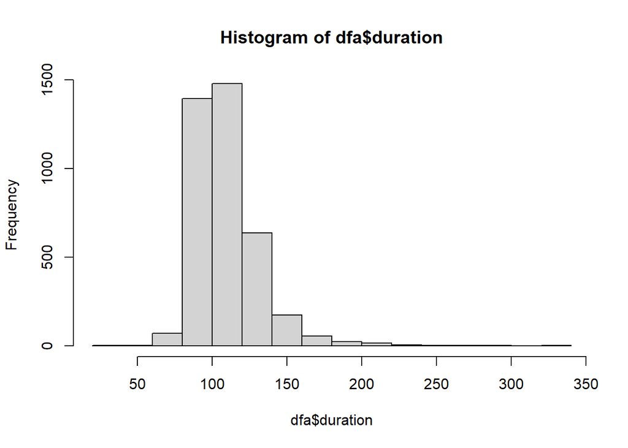

```r
hist(dfa$duration)
```

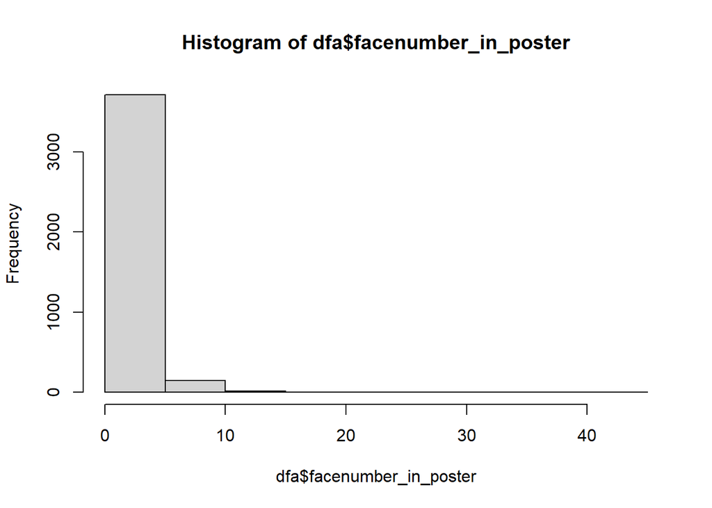

```r
hist(dfa$facenumber_in_poster)
```

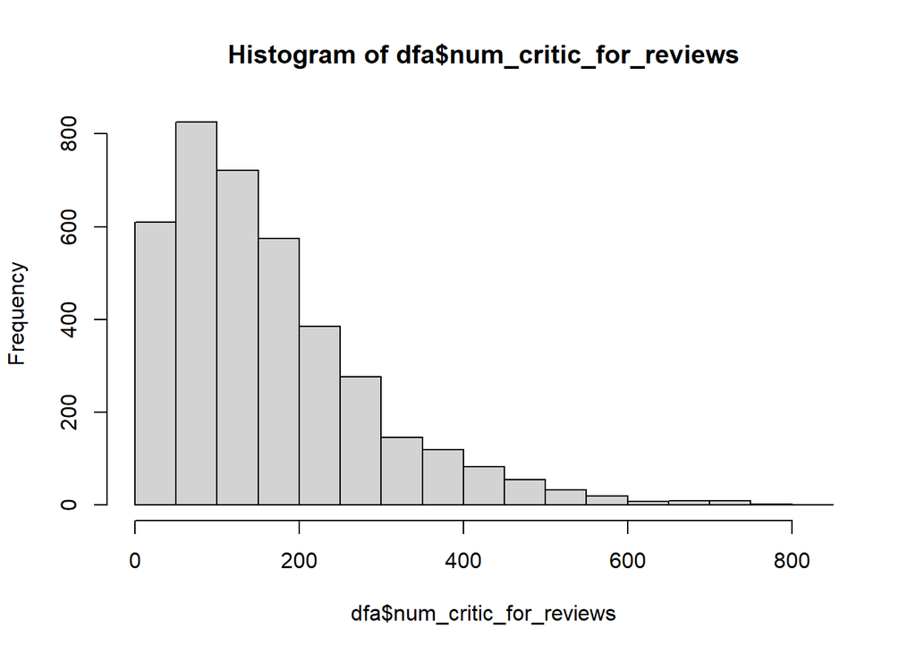

```r
hist(dfa$num_critic_for_reviews)
```

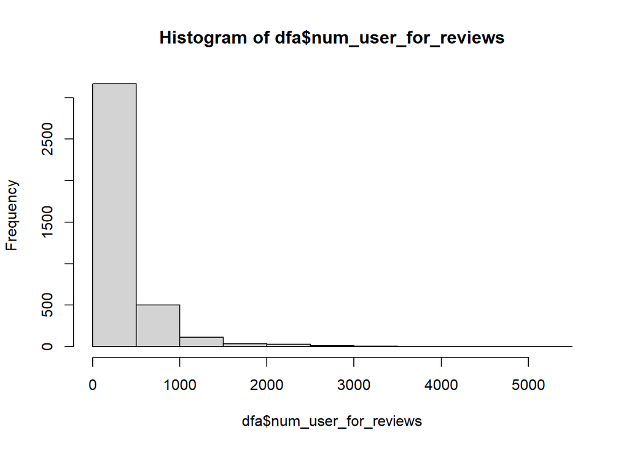

```r
hist(dfa$num_user_for_reviews)
```

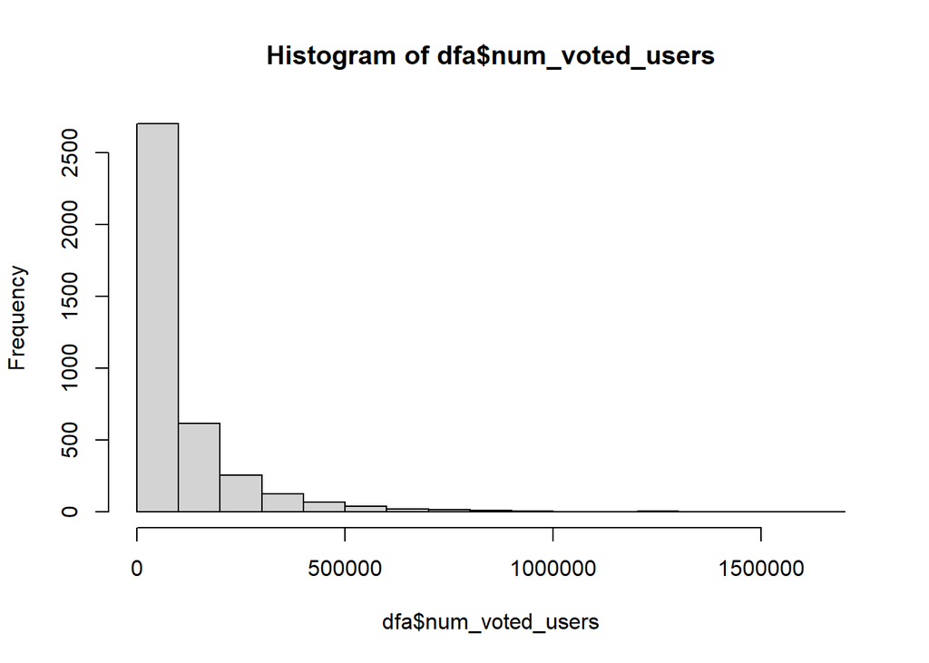

```r
hist(dfa$num_voted_users)
```

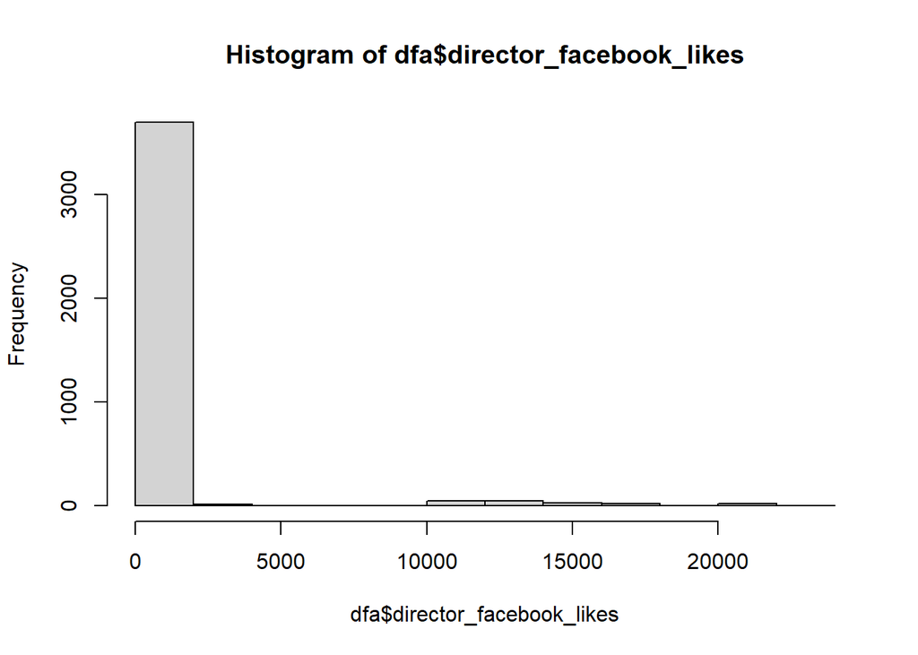

```r
hist(dfa$director_facebook_likes)
```

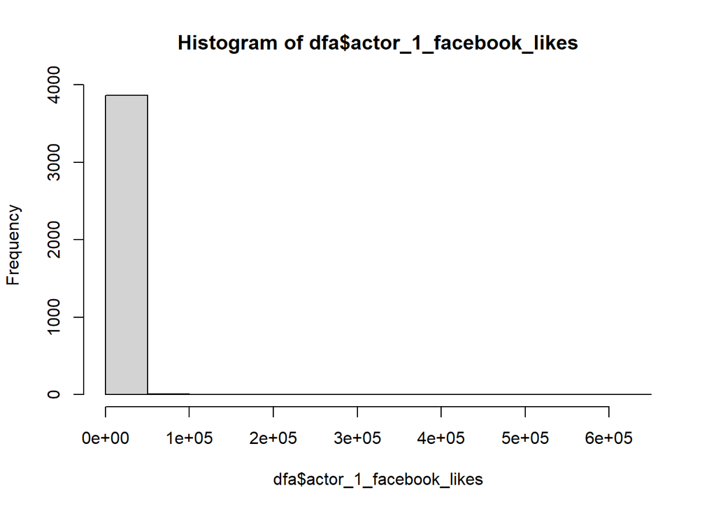

```r
hist(dfa$actor_1_facebook_likes)
```

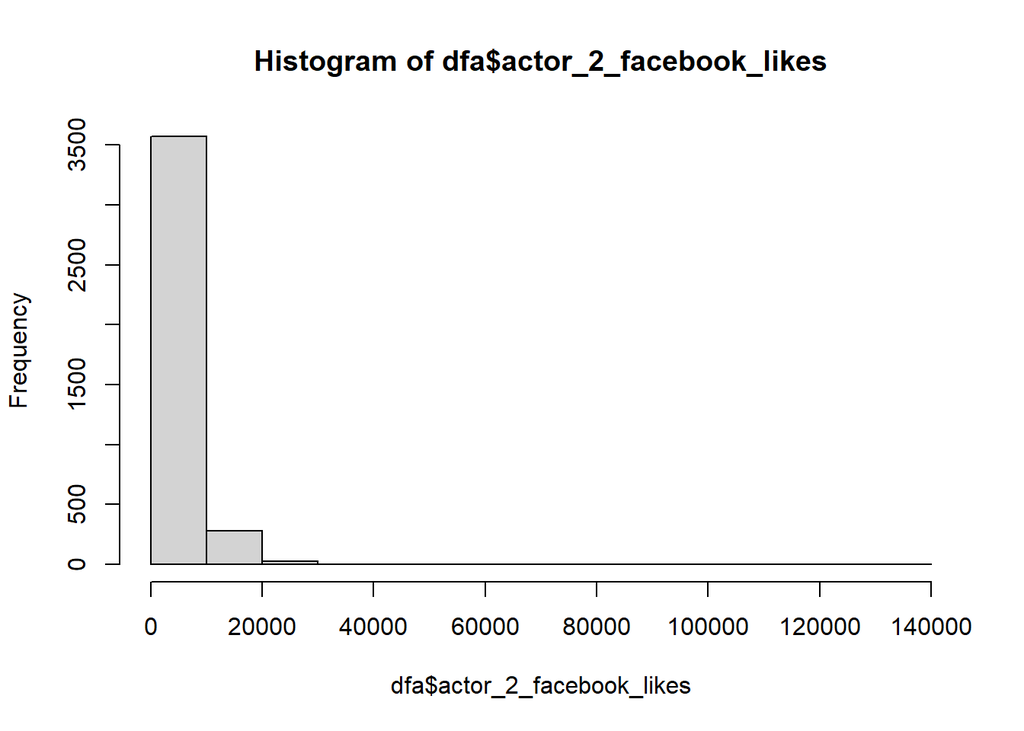

```r
hist(dfa$actor_2_facebook_likes)
```

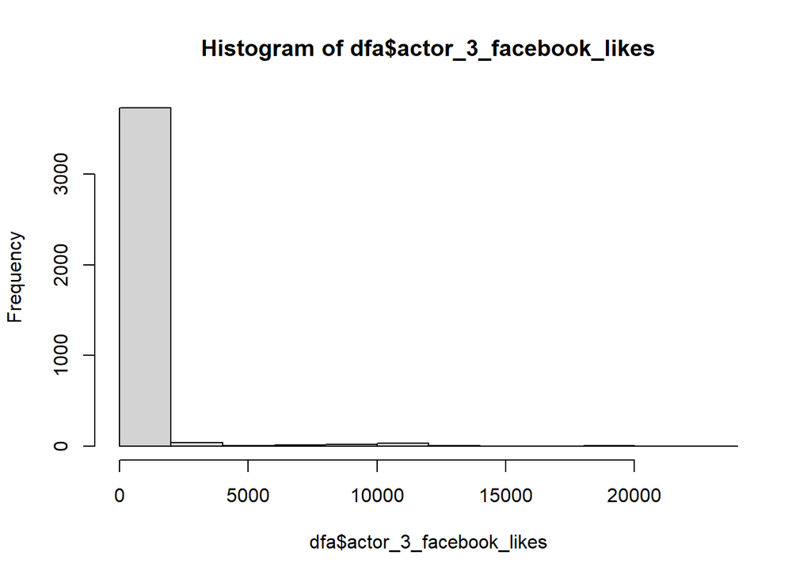

```r
hist(dfa$actor_3_facebook_likes)
```

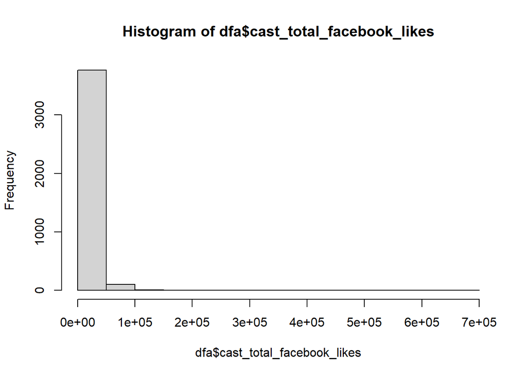

```r
hist(dfa$cast_total_facebook_likes)
```

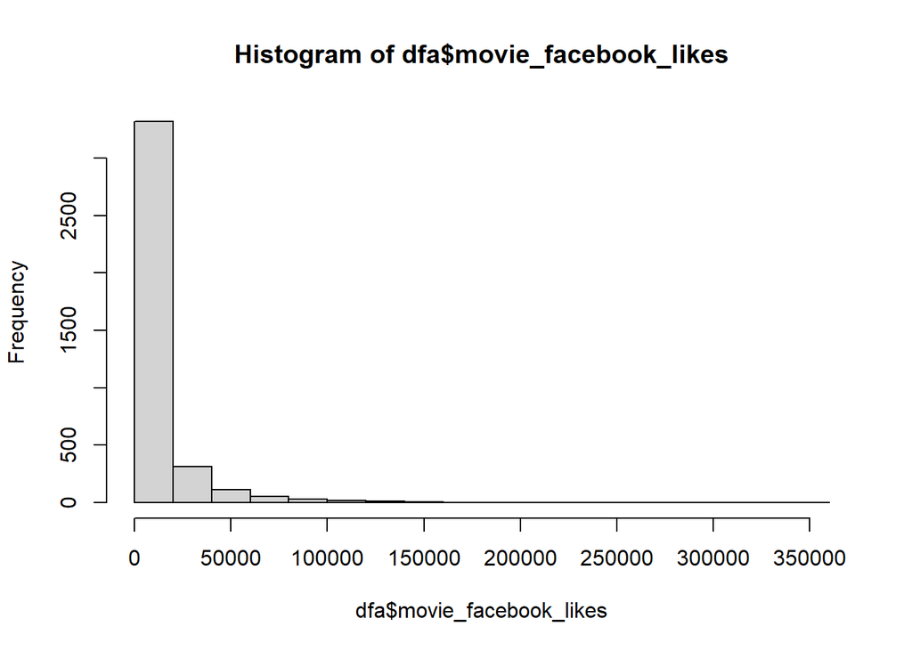

```r
hist(dfa$movie_facebook_likes)
```